# **Proyecto 1 – Relación Minutos Ingreso**

# **Integrantes (2 Personas):**

**Daniel Santiago Gonzalez Citelly**

**Leandro Reyes Jordan**

## **3.Creen una carpeta para alojar su proyecto, ahí descarguen la base Credito_dias.csv**

```python
#Importamos las librerias principales.
import pandas as pd
import matplotlib.pyplot as plt
import seaborn as sns
from scipy.stats import ttest_ind
import numpy as np
```

```python
#Definición de ruta y cargue de la base de datos.
link = 'https://raw.githubusercontent.com/Izainea/seminario-de-programacion/master/Cuadernos/Clase%202/Bases/Credito_dias.csv'
df = pd.read_csv(link)
print("Se ha creado satisfactoriamente el repositorio!")
```

```
Se ha creado satisfactoriamente el repositorio!
```

## **4. Hagan una celda tipo MarkDown y escriban:**

### **C. Una explicación breve del problema teniendo en cuenta lo siguiente:**

¿Existe relación alguna entre el total de minutos usados con la compañía y el ingreso total de los clientes?

La revisión del comportamiento de los clientes en cualquier empresa es de vital importancia para el desarrollo de estrategias, tanto de mejoramiento de productos, como de publicidad y toma de decisiones. Evaluaremos la información del conjunto de registros Credito_dias.csv de una empresa de telecomunicaciones que cuenta las siguientes variables:

- totrev: Ingresos del cliente.
- totmou: Total de minutos usados por el cliente.
- creditcd: Indicador de tarjeta de crédito.
- eqpdays: Número de días (antigüedad) del equipo actual.

Es importante mencionar que la empresa contiene una gran cantidad de clientes y hacer el análisis uno a uno no es lo óptimo. Con ayuda de la programación y el análisis de datos, se logrará llegar a conclusiones rápidas y acertadas para encontrar relaciones que a simple vista no son tenidas en cuenta.

¿Qué se quiere identificar?

Teniendo en cuenta la información de la base de datos, se quiere identificar si hay una relación entre el total de minutos usados por el cliente con la compañía y el ingreso total de los clientes, es decir, ¿Será posible afirmar que cuando una persona tiene un mayor ingreso, entonces es mayor la utilización de minutos o todo lo contrario?

### **Explicación del problema planteado:**

El problema planteado implica la identificación de una posible relación entre dos variables clave para la empresa de telecomunicaciones: el total de minutos utilizados por el cliente y los ingresos totales generados por ese cliente. En otras palabras, se busca determinar si existe una asociación significativa entre la cantidad de minutos que un cliente utiliza con la compañía y la cantidad de ingresos que genera para la empresa.

Teniendo en cuenta la importancia de este ejercicio para la empresa, ya que entender cómo los patrones de uso de los servicios de telecomunicaciones están vinculados con los ingresos, puede proporcionar información valiosa para el desarrollo de estrategias comerciales, mejoramiento de productos y decisiones de inversión en publicidad.

Para abordar este problema, se utilizarán técnicas de análisis de datos y estadísticas para explorar la relación entre las variables totmou (total de minutos utilizados) y totrev (ingresos totales), teniendo en cuenta también otras variables relevantes como el indicador de tarjeta de crédito (creditcd).

Al identificar y comprender la naturaleza de la relación entre estos dos factores, la empresa podrá tomar decisiones más informadas y estratégicas para optimizar sus servicios y maximizar sus ingresos.

## **5. Incluyan un exploratorio separado por cada una de las variables que se tienen en esta base se sugiere que use histogramas para las variables numéricas y diagramas de barras para las categóricas.**

```python
# Normalizamos las variables de acuerdo a la tipología de variable.

df['totmou'] = df['totmou'].astype(float)
df['totrev'] = df['totrev'].astype(float)
df['eqpdays'] = df['eqpdays'].astype(int)
df['creditcd'] = df['creditcd'].astype(str)
df['Customer_ID'] = df['Customer_ID'].astype(str)

print("La información general sobre los datos es:\n")
df.info()
```

```
La información general sobre los datos es:

<class 'pandas.core.frame.DataFrame'>
RangeIndex: 10000 entries, 0 to 9999
Data columns (total 5 columns):
 #   Column       Non-Null Count  Dtype
---  ------       --------------  -----
 0   totmou       10000 non-null  float64
 1   totrev       10000 non-null  float64
 2   creditcd     10000 non-null  object
 3   eqpdays      10000 non-null  int32
 4   Customer_ID  10000 non-null  object
dtypes: float64(2), int32(1), object(2)
memory usage: 351.7+ KB
```

```python
print("Las primeras filas de los datos son:")
df.head()
```

```
Las primeras filas de los datos son:
```

|  | totmou | totrev | creditcd | eqpdays | Customer_ID |
| --- | --- | --- | --- | --- | --- |
| 0 | 7269.0 | 906.58 | Y | 371 | 1082423 |
| 1 | 13552.0 | 1172.25 | N | 83 | 1069232 |
| 2 | 4152.0 | 577.39 | Y | 675 | 1031705 |
| 3 | 1863.0 | 294.26 | Y | 218 | 1089806 |
| 4 | 4155.0 | 433.16 | N | 222 | 1076695 |

```python
print("El resumen estadístico de los datos numéricos es:")
df.describe()
```

```
El resumen estadístico de los datos numéricos es:
```

|  | totmou | totrev | eqpdays |
| --- | --- | --- | --- |
| count | 10000.000000 | 10000.000000 | 10000.000000 |
| mean | 7692.804866 | 1042.133807 | 386.794500 |
| std | 8657.917883 | 857.144895 | 252.720196 |
| min | 0.000000 | 11.100000 | -5.000000 |
| 25% | 2576.000000 | 526.787500 | 210.000000 |
| 50% | 5262.000000 | 820.235000 | 338.000000 |
| 75% | 9823.250000 | 1272.975000 | 522.000000 |
| max | 163264.176700 | 13426.600000 | 1823.000000 |

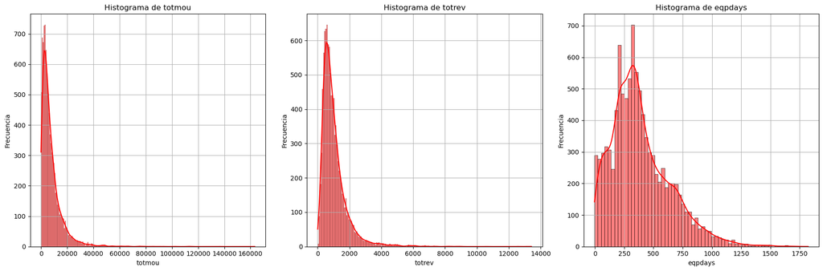

```python
# Histogramas para las variables numéricas
numeric_vars = ["totmou", "totrev", "eqpdays"]
fig, axs = plt.subplots(1, 3, figsize=(18, 6))  # Grafico con dimensiones de 1x3

for i, var in enumerate(numeric_vars):
    sns.histplot(df[var], kde=True, color='red', ax=axs[i])
    axs[i].set_title(f'Histograma de {var}')
    axs[i].set_xlabel(var)
    axs[i].set_ylabel('Frecuencia')
    axs[i].grid(True)

plt.tight_layout()
plt.show()
```

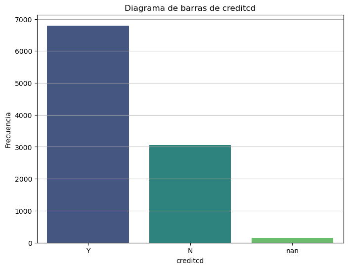

```python
# Diagramas de barras para las variables categóricas
categorical_vars = ["creditcd"]
for var in categorical_vars:
    plt.figure(figsize=(8, 6))
    sns.countplot(data=df, x=var, palette='viridis')
    plt.title(f'Diagrama de barras de {var}')
    plt.xlabel(var)
    plt.ylabel('Frecuencia')
    plt.grid(axis='y')
    plt.show()
```

## **6. Hagan un diagrama de dispersión entre las variables totrev y totmou. Posterior a la realización de este gráfico desarrolle una conclusión.**

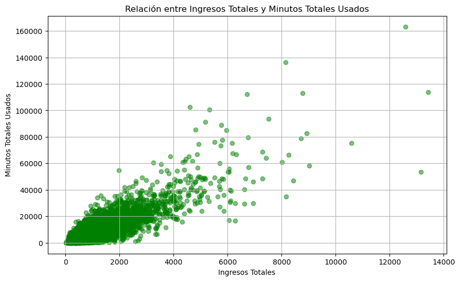

```python
# Diagrama de dispersión entre las variables totrev y totmou.
plt.figure(figsize=(10, 6))
plt.scatter(df.totrev, df.totmou, color='green', alpha=0.5)

plt.title('Relación entre Ingresos Totales y Minutos Totales Usados')
plt.xlabel('Ingresos Totales')
plt.ylabel('Minutos Totales Usados')
plt.grid(True)
plt.show()
```

### **Conclusiones del diagrama de dispersión:**

**- Concentración de datos:** Hay una concentración de puntos de datos en la esquina inferior izquierda del gráfico. Esto indica que hay muchos casos donde tanto ‘totmou’ como ‘totrev’ son relativamente bajos.

**- Valores atípicos:** Hay algunos puntos de datos aislados en valores más altos de ‘totmou’. Estos podrían ser valores atípicos y podrían indicar casos especiales o errores en los datos.

## **7. Respondan ¿Existe relación alguna entre el total de minutos usados con la compañía y el ingreso total de los clientes?**

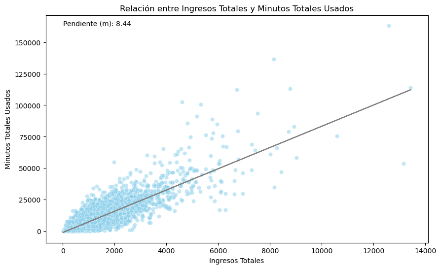

```
Correlación entre totrev y totmou: 0.8354845922593955
```

```python
# Cálculo de la correlación entre las variables totrev y totmou
correlacion = df['totrev'].corr(df['totmou'])

# Línea de regresión lineal
x = df['totrev']
y = df['totmou']
m, b = np.polyfit(x, y, 1)

# Visualización
plt.figure(figsize=(10, 6))
sns.scatterplot(x='totrev', y='totmou', data=df, color='skyblue', alpha=0.5)
plt.text(x.min(), y.max(), f'Pendiente (m): {m:.2f}', fontsize=10, color='black')

plt.plot(x, m*x + b, color='gray')  # trazar la línea de regresión con color gris

plt.title('Relación entre Ingresos Totales y Minutos Totales Usados')
plt.xlabel('Ingresos Totales')
plt.ylabel('Minutos Totales Usados')
plt.show()

print("Correlación entre totrev y totmou:", correlacion)
```

Teniendo en cuenta que una correlación de 1 indica una correlación positiva perfecta, lo que significa que las dos variables están linealmente relacionadas de manera positiva; es decir, a medida que una variable aumenta, la otra también lo hace en proporción constante.

El valor de correlación obtenido de 0.8354 indica una correlación positiva fuerte entre las dos variables ingresos totales de los clientes ("totrev") y los minutos totales usados por los clientes ("totmou").

Por lo tanto, este resultado indica que hay una fuerte tendencia positiva entre los ingresos totales y los minutos totales usados por los clientes, lo que sugiere que en general los clientes que generan mayores ingresos también tienden a utilizar más minutos de servicio.

La pendiente de la línea (m) indica el aumento de totmou en promedio(8.44) cuando totrev aumenta en una unidad.

## **8. El hecho de tener crédito afecta alguna de estas dos variables, compruébenlo incluyendo en el diagrama de dispersión una leyenda que indique si tiene crédito o no.**

Para incluir información sobre si los clientes tienen crédito o no en el diagrama de dispersión, se ajusta el código para utilizar color azúl para los clientes que tienen crédito y color rojo para los que no lo tienen.

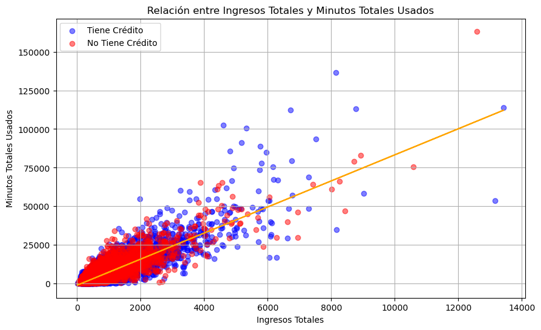

```python
# Cálculo de la correlación entre las variables totrev y totmou
correlacion = df['totrev'].corr(df['totmou'])

# Línea de regresión lineal
x = df['totrev']
y = df['totmou']
m, b = np.polyfit(x, y, 1)

# Gráfica de dispersión ajustada para categorizar los cliente en función de si tienen crédito o no lo tienen
plt.figure(figsize=(10, 6))

# Gráfica de dispersión para los clientes con crédito
plt.scatter(df[df['creditcd'] == 'Y']['totrev'], df[df['creditcd'] == 'Y']['totmou'], c='blue', alpha=0.5, label='Tiene Crédito')

# Gráfica de dispersión para los clientes sin crédito
plt.scatter(df[df['creditcd'] == 'N']['totrev'], df[df['creditcd'] == 'N']['totmou'], c='red', alpha=0.5, label='No Tiene Crédito')
plt.plot(x, m*x + b, color='orange')
plt.title('Relación entre Ingresos Totales y Minutos Totales Usados')
plt.xlabel('Ingresos Totales')
plt.ylabel('Minutos Totales Usados')
plt.grid(True)
plt.legend()
plt.show()
```

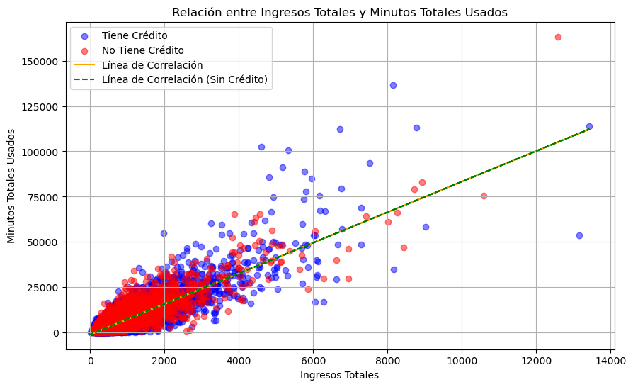

```
Correlación para clientes con crédito: 0.8300142886656408
Correlación para clientes sin crédito: 0.8506198048016032
```

```python
# Cálculo de la correlación entre las variables totrev y totmou
correlacion = df['totrev'].corr(df['totmou'])

# Línea de regresión lineal
x = df['totrev']
y = df['totmou']
m, b = np.polyfit(x, y, 1)

# Gráfica de dispersión ajustada para categorizar los clientes en función de si tienen crédito o no lo tienen
plt.figure(figsize=(10, 6))

# Gráfica de dispersión para los clientes con crédito
plt.scatter(df[df['creditcd'] == 'Y']['totrev'], df[df['creditcd'] == 'Y']['totmou'], c='blue', alpha=0.5, label='Tiene Crédito')

# Gráfica de dispersión para los clientes sin crédito
plt.scatter(df[df['creditcd'] == 'N']['totrev'], df[df['creditcd'] == 'N']['totmou'], c='red', alpha=0.5, label='No Tiene Crédito')

# Línea de correlación para clientes con crédito
plt.plot(x, m*x + b, color='orange', label='Línea de Correlación')

# Línea de correlación para clientes sin crédito
plt.plot(x, m*x + b, color='green', linestyle='dashed', label='Línea de Correlación (Sin Crédito)')

plt.title('Relación entre Ingresos Totales y Minutos Totales Usados')
plt.xlabel('Ingresos Totales')
plt.ylabel('Minutos Totales Usados')
plt.grid(True)
plt.legend()
plt.show()

# Calcular correlaciones para clientes con crédito
correlacion_con_credito = df[df['creditcd'] == 'Y']['totrev'].corr(df[df['creditcd'] == 'Y']['totmou'])

# Calcular correlaciones para clientes sin crédito
correlacion_sin_credito = df[df['creditcd'] == 'N']['totrev'].corr(df[df['creditcd'] == 'N']['totmou'])

# Mostrar correlaciones
print("Correlación para clientes con crédito:", correlacion_con_credito)
print("Correlación para clientes sin crédito:", correlacion_sin_credito)
```

Con base en el diagrama de dispersión que muestra la relación entre los ingresos totales de los clientes, los minutos totales usados y si tienen o no crédito, se tienen las siguiente conclusiones:

**- Relación entre ingresos totales y minutos totales usados:**

Se observa una tendencia general en la que los clientes que generan mayores ingresos tienden a utilizar más minutos de servicio, el cual se puede ver claramente en la gráfica a partir de aproximadamente 4400 de ingresos totales . Esto sugiere que hay una relación positiva entre estas dos variables: a medida que aumentan los ingresos totales de los clientes, también tienden a aumentar los minutos totales utilizados

**- Impacto del crédito en la relación:**

Al incorporar la información sobre si los clientes con relación a si tienen o no tarjeta de crédito en el diagrama de dispersión, se puede ver cómo esta variable se relaciona con los ingresos totales y los minutos totales utilizados. Sin embargo, el diagrama de dispersión no proporciona suficiente información para analizar el impacto de la variable creditcd sobre las variables totmou y totrev y las correlaciones independientes no muestran una diferencia significativa (Clientes con crédito: 0.8300 vs Clientes sin crédito: 0.8506). Por lo tanto, se propone realizar la prueba de hipótesis t-student para determinar si hay alguna diferencia significativa en totrev y totmou.

```python
# Prueba de hipótesis t-student

# División del DataFrame en dos grupos según si tienen o no tarjeta de crédito
group_with_credit = df[df['creditcd'] == 'Y']
group_without_credit = df[df['creditcd'] == 'N']

# Cálculo de las estadísticas descriptivas de cada variable
desc_stats_with_credit = group_with_credit[['totrev', 'totmou']].describe()
desc_stats_without_credit = group_without_credit[['totrev', 'totmou']].describe()

# Prueba t para comparar las dos muestras
t_statistic_totrev, p_value_totrev = ttest_ind(group_with_credit['totrev'], group_without_credit['totrev'])
t_statistic_totmou, p_value_totmou = ttest_ind(group_with_credit['totmou'], group_without_credit['totmou'])

print("Prueba t para totrev - Estadística t: {:.4f}, Valor p: {:.4f}".format(t_statistic_totrev, p_value_totrev))
print("Prueba t para totmou - Estadística t: {:.4f}, Valor p: {:.4f}".format(t_statistic_totmou, p_value_totmou))
```

```
Prueba t para totrev - Estadística t: 0.4925, Valor p: 0.6224
Prueba t para totmou - Estadística t: -4.5395, Valor p: 0.0000
```

Conforme a los resultados de la prueba t-student, para el caso de la variable totrev, el valor p es 0.6224, lo que significa que no hay evidencia suficiente para rechazar la hipótesis nula. Por lo tanto, no se puede concluir que haya una diferencia significativa en los ingresos (totrev) entre los clientes con tarjeta de crédito y los que no la tienen.

## **9. Guardar y exportar como .html**

Se envía archivo en formato HTML cargado en GitHub